# CH4_PoolDilution

Kendalynn A. Morris

2022-10-27

## Methane Pool Dilution

This code calculates gross methane production and consumption from pool dilution time series data. Methane concentrations and 13C content are measured from a closed system over time, the model optimizes production rate (P) and the first order rate constant (k), but minimizing error in the model-predicted total methane content, as well as the isotopic signature.  
Up-coming improvements include modifying the model to include weighting information against the signal:noise ratio of concentration and 13C-signature using instrument precision and measurement errors.

```r
# Get names of data files
files <- list.files("picarro/", pattern = "*.csv", full.names = TRUE)
# Helper function
read_file <- function(f) {
    message("Reading ", f)
    read_csv(f, col_types = "ccdcddcddddddddddddddddddddddccccc") %>%
        mutate(File = basename(f))
}
# Read in and pre-process data
lapply(files, read_file) %>%
    bind_rows() %>%
    # filter out standards and clean up columns
    filter(! id %in% c("SERC100ppm", "UMDzero", "SERCzero", "desert5000")) %>%
    mutate(Timestamp = mdy_hm(`Date/Time`, tz = "UTC")) %>%
    select(Timestamp, id, round, vol,
           `HR 12CH4 Mean`, `HR 12CH4 Std`,
           `HR 13CH4 Mean`, `HR 13CH4 Std`,
           `HR Delta iCH4 Mean`, `HR Delta iCH4 Std`,
           `12CO2 Mean`, `12CO2 Std`,
           `13CO2 Mean`, `13CO2 Std`,
           `Delta 13CO2 Mean`, `Delta 13CO2 Std`,
           notes) %>%
    # calculate elapsed time for each sample
    arrange(id, round) %>%
    group_by(id) %>%
    mutate(time_days = difftime(Timestamp, min(Timestamp),
                                units = "days"),
           time_days = as.numeric(time_days)) ->
    incdat_raw
```

```
## Reading picarro/CFIDS2333_SSIM_20220728_121056.csv
```

```
## Reading picarro/CFIDS2333_SSIM_20220729_180423.csv
```

```
## Reading picarro/CFIDS2333_SSIM_20220730_122504.csv
```

```
## Reading picarro/CFIDS2333_SSIM_20220731_120811.csv
```

```r
summary(incdat_raw)
```

```
##    Timestamp                           id               round
##  Min.   :2022-07-28 12:51:00.00   Length:193         Length:193
##  1st Qu.:2022-07-28 22:06:00.00   Class :character   Class :character
##  Median :2022-07-30 17:04:00.00   Mode  :character   Mode  :character
##  Mean   :2022-07-30 09:33:47.55
##  3rd Qu.:2022-07-31 14:28:00.00
##  Max.   :2022-07-31 22:18:00.00
##       vol     HR 12CH4 Mean     HR 12CH4 Std      HR 13CH4 Mean
##  Min.   :10   Min.   : 0.556   Min.   :0.005000   Min.   :0.00700
##  1st Qu.:10   1st Qu.: 0.911   1st Qu.:0.007000   1st Qu.:0.01100
##  Median :10   Median : 1.468   Median :0.008000   Median :0.01900
##  Mean   :10   Mean   : 2.524   Mean   :0.008378   Mean   :0.03296
##  3rd Qu.:10   3rd Qu.: 2.870   3rd Qu.:0.009000   3rd Qu.:0.04000
##  Max.   :10   Max.   :29.922   Max.   :0.034000   Max.   :0.33200
##   HR 13CH4 Std HR Delta iCH4 Mean HR Delta iCH4 Std   12CO2 Mean
##  Min.   :0     Min.   :-68.82     Min.   : 0.496    Min.   : 179.3
##  1st Qu.:0     1st Qu.:-15.98     1st Qu.: 4.363    1st Qu.: 388.7
##  Median :0     Median :146.57     Median : 8.041    Median : 618.3
##  Mean   :0     Mean   :113.69     Mean   : 8.221    Mean   : 804.2
##  3rd Qu.:0     3rd Qu.:220.75     3rd Qu.:12.003    3rd Qu.:1048.7
##  Max.   :0     Max.   :317.30     Max.   :17.232    Max.   :3126.4
##    12CO2 Std        13CO2 Mean       13CO2 Std        Delta 13CO2 Mean
##  Min.   :0.1570   Min.   : 2.054   Min.   :0.004000   Min.   :-26.440
##  1st Qu.:0.2990   1st Qu.: 4.413   1st Qu.:0.006000   1st Qu.:-23.311
##  Median :0.4450   Median : 6.981   Median :0.007000   Median :-20.561
##  Mean   :0.5597   Mean   : 9.061   Mean   :0.007902   Mean   :-19.333
##  3rd Qu.:0.7390   3rd Qu.:11.806   3rd Qu.:0.009000   3rd Qu.:-15.669
##  Max.   :1.9500   Max.   :34.864   Max.   :0.023000   Max.   : -6.859
##  Delta 13CO2 Std     notes             time_days
##  Min.   :0.2520   Length:193         Min.   :0.00000
##  1st Qu.:0.5250   Class :character   1st Qu.:0.02708
##  Median :0.7180   Mode  :character   Median :0.05556
##  Mean   :0.9053                      Mean   :0.06090
##  3rd Qu.:1.2200                      3rd Qu.:0.08889
##  Max.   :2.4220                      Max.   :0.31319
```

## Input Data Visualizaton

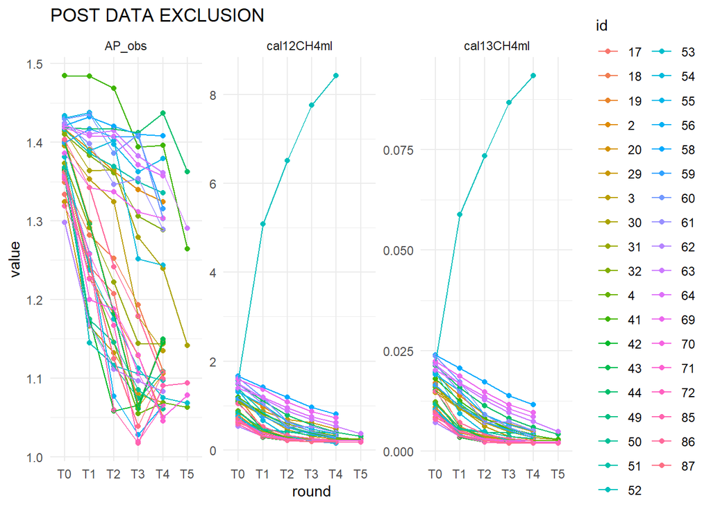

## Atom Precent Prediction

Prediction function  
time: vector of time values, numeric (e.g. days); first should be zero  
m0: amount of total methane at time zero  
n0: amount of labeled methane at time zero  
P: production rate of total methane, unit gas/unit time  
k: first-order rate constant for methane consumption, 1/unit time  
Returns a data frame with mt, nt, and AP (atom percent) predictions for each t

# Cost Function

Called by optim()  
params: named vector holding optimizer-assigned values for P and k time: vector of time values, numeric (e.g. days); first should be zero m: observed total methane values, same length as time n: observed labeled methane values, same length as time Returns the sum of squares between predicted and observed m and AP

#### Here is where the signal:noise ratio optimization needs to be incorporated.

# Optimize

```
## # A tibble: 37 × 8
##    id     m_cor ap_cor      P       k    k0 convergence message
##    <chr>  <dbl>  <dbl>  <dbl>   <dbl> <dbl>       <int> <chr>
##  1 17     1.00   0.895  5.33  26.7    10.7            0 CONVERGENCE: REL_REDUCT…
##  2 18     0.999  0.963  6.23  28.9    11.5            0 CONVERGENCE: REL_REDUCT…
##  3 19     1.00   0.988 12.5   53.0    17.3            0 CONVERGENCE: REL_REDUCT…
##  4 2      0.998 -0.994  0     12.3    13.2            0 CONVERGENCE: REL_REDUCT…
##  5 20     1.00   0.968 11.7   51.3    13.1            0 CONVERGENCE: REL_REDUCT…
##  6 29     0.996  0.738  0.722  8.52    9.59           0 CONVERGENCE: REL_REDUCT…
##  7 3      0.999  0.951  1.15  16.7    16.3            0 CONVERGENCE: REL_REDUCT…
##  8 30    -0.815  0.754 64.9    0.0001  8.01           0 CONVERGENCE: REL_REDUCT…
##  9 31     0.999  0.980  4.87  26.7    14.0            0 CONVERGENCE: REL_REDUCT…
## 10 32     1.00   0.832  0.672 12.7    12.6            0 CONVERGENCE: REL_REDUCT…
## # … with 27 more rows
```

## Summary Plots

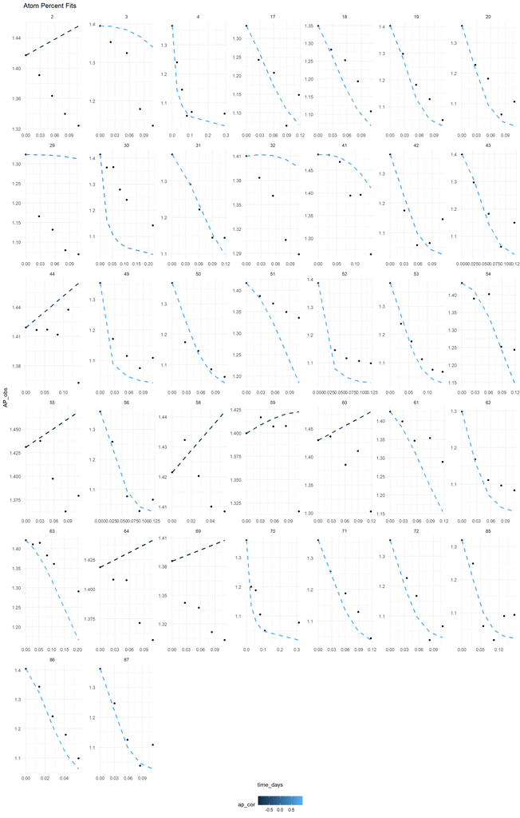

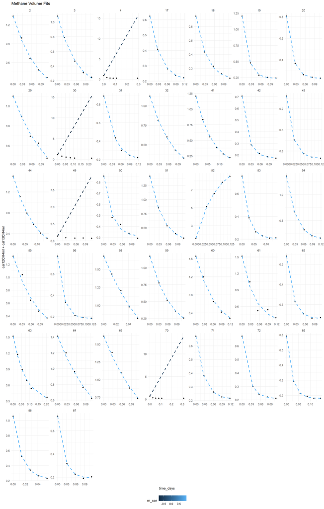

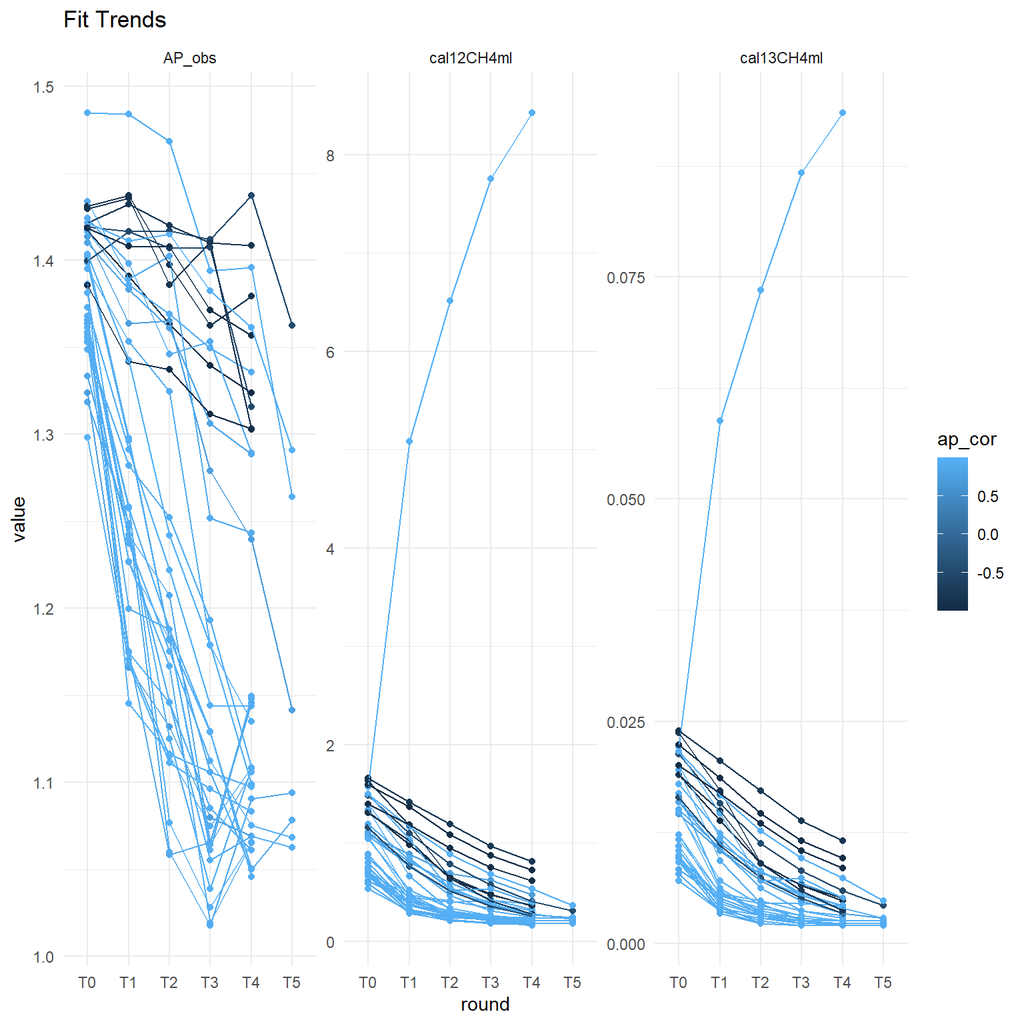

```
## All done. :)
```